# Introduction

Author

Corwin Dark

## Topic Explanation:

In this project I will study the daily volatility of major US stock indices over time, specifically the Standard and Poors 500, the Russel 2000, and the NASDAQ 100. By volatility, I specifically mean the intraday range in prices that these indices take on the open market. I will both review these intraday ranges as univariate time series, and also attempt to shed light on variables that impact volatility by incorporating external factors. I will look at warnings of extreme weather events, investor confidence metrics, future bond rate expectations, and work stoppage data on strikes and striking workers. Using the statistical models we have learned in class, I hope to investigate the relationships between these factors and stock market volatility.

## The Big Picture:

Financial markets are directly important to the well-being of everyday Americans. While the stock market is often seen as exclusive to a small circle of elite investors, in reality millions of Americans have exposure to the markets through retirement funds, which are made up of many different kinds of investments. If we can become better at predicting the course of financial markets, particularly in relation to external forces like climate change, it could promise to reduce volatility and inefficiency in the market. In turn, this would help everyday people build up their savings to enjoy a better quality of life, retire sooner, and have more financial security.

Further, understanding the movements of financial markets is important in controlling sentiment amongst investors. In cases like the onset of the COVID-19 pandemic, stock market crashes could snowball into businesses cutting more jobs than needed, which could directly impact peoples’ livelihoods. By looking at extreme events such as major strikes and severe weather warnings, I hope to elucidate the effect of these changes.

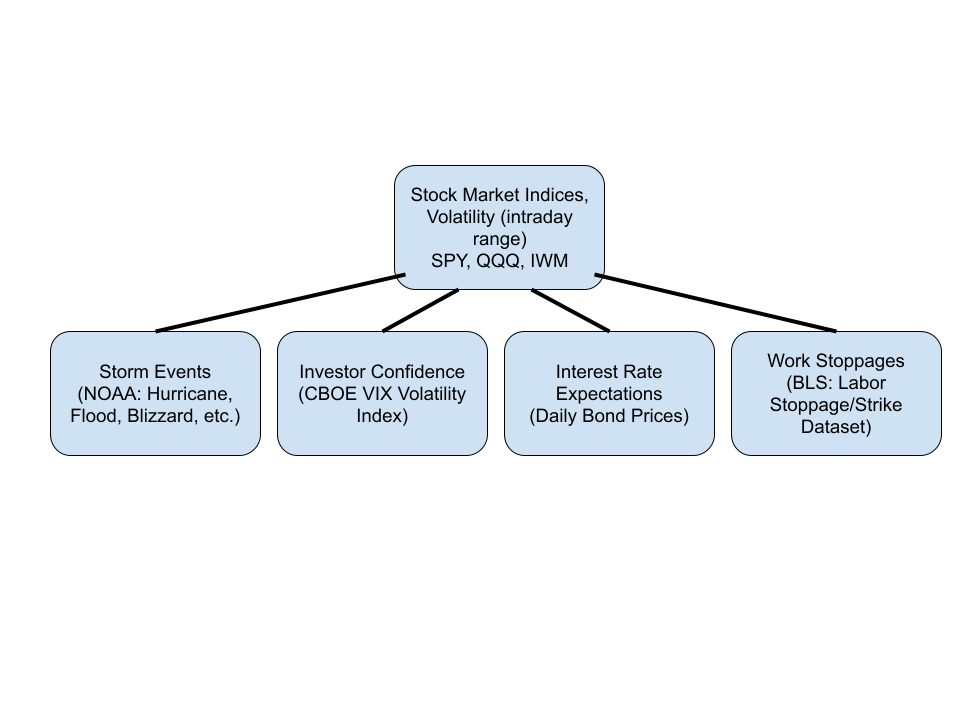

Big Picture

## Analytical Angles:

The price of stock market indices are considered to be noisy and near-impossible to predict. Related values such as intraday range are also expected to be difficult to predict with any accuracy (given that any such prediction could yield profit and should be closed under the efficient market hypothesis).

First, looking at intraday volatility as univariate time series. Conceptually, this means studying the securities in a vacumn, and assuming no external information will determine their future while. While this approach might seem naive, it actually mirrors how some financial institutions might manage risk, where you look to a stocks past volatility to determine future volatility.

Second, understanding intraday volatility as a series of values which are reflective of individuals actions and preferences. In this case, the individuals in question are investors, and we will look at investor sentiment and see how it might affect prices in financial markets.

Third, viewing intraday volatility in the context of external stimuli. From this analytical perspective, the stock market is a closed system, which is disrupted by external forces from time-to-time that cause unexpected behaviour. Studying the impact of extreme weather events and work stoppages relate to this point.

Fourth, understanding intraday volatility as an output variable of larger expectations in the financial system. By looking at changes in future bond prices (i.e. predictions for future bond rates), we can understand how indices react to shifting financial conditions overall.

## Literature Review:

Many of the factors this project seeks to investigate have previously been reviewed by academics. For instance, the consequence of investor sentiment on the stock market has been widely studied, in terms of how it impacts stock market crises (Zouaoui, Nouyrigat, and Beer 2011), trading volume (So and Lei 2015), and especially returns (Smales 2017). Further, authors have previously found an impact of climate events, such as hurricanes (Liu, Ferreira, and Karali 2021) on stock prices of particular companies. The fact that these issues have been studied previously is encouraging, because in each case the authors chose a specific group of time and company limited stock market data. This project might extend their results to other stock market datasets, and might hope to incorporate these relationships into new statistical models.

## Guiding Questions:

1. Is the intraday volatility of major stock indices truly random, or does it contain patterns that can be modelled?
2. Do the major US stock indices differ greatly in the structure of their volatility over time?
3. How do markets react in response to chaining expectations about macroeconomic conditions?
4. How do markets incorporate extreme weather event warnings into their pricing of major indices, and how does this affect volatility?
5. How do markets react in response to major strikes and labor stoppages, and does this differ based on the size of the strike or the types of companies in question?
6. How does investor confidence impact markets?
7. Do the major US stock indices differ in their response to external stimuli, and are some more sensitive to external volitility?
8. Are the patterns exhibited by intraday volatility in major indices best-suited to traditional statistical models or deep learning? If deep learning models fit better, then what does that say about patterns in volatility?
9. Have the relationships between the intraday ranges in the prices of securities and external factors changed over time?
10. How well can we explain variations in intraday volatility, when synthesizing as much external data and models as possible?

## References

Liu, Haiyan, Susana Ferreira, and Berna Karali. 2021. “Hurricanes as News? Assessing the Impact of Hurricanes on the Stock Market Returns of Energy Companies.” *International Journal of Disaster Risk Reduction* 66 (December): 102572. https://doi.org/10.1016/j.ijdrr.2021.102572.

Smales, L. A. 2017. “The Importance of Fear: Investor Sentiment and Stock Market Returns.” *Applied Economics* 49 (34): 3395–3421. https://doi.org/10.1080/00036846.2016.1259754.

So, Simon Man Shing, and Violet U. T. Lei. 2015. “On the Relationship Between Investor Sentiment, VIX and Trading Volume.” *Risk Governance and Control: Financial Markets and Institutions* 5 (4): 114–22. https://doi.org/10.22495/rgcv5i4c1art1.

Zouaoui, Mohamed, Geneviève Nouyrigat, and Francisca Beer. 2011. “How Does Investor Sentiment Affect Stock Market Crises? Evidence from Panel Data.” *Financial Review* 46 (4): 723–47. https://doi.org/10.1111/j.1540-6288.2011.00318.x.